# DS400: Assignment III (R)

Mohamed Elsherif (Student ID: 6378374)

2024-12-18

### Directory set up & Libraries Installation

```r
# Load all libraries needed
library(rstudioapi)
library(readr)
library(data.table)
```

```r
library(ggplot2)
library(lubridate)
library(tidyr)
library(dplyr)
library(scales)
library(class)
library(RColorBrewer)
options(warn = -1)
```

```r
# Set working directory to the R md location
library(here)
knitr::opts_chunk$set(root.dir = here::here())
cat("Current working directory is:", getwd(), "\n")
```

```
## Current working directory is: /Users/dr.elsherif/Downloads/Assignment03
```

```r
artificial_data <- read_csv("./data/artificial_data.csv")
```

## Functional Programming

### Part 1: Function describe_data()

#### 1.[R] Program a function that describes a dataset. The function should be called describe_data() and take an R dataframe as input.

```r
# Convert 'gender' and 'adult' columns from character to factor
artificial_data$gender <- factor(artificial_data$gender)
artificial_data$adult <- factor(artificial_data$adult)

describe_data <- function(df) {
  # Get number of rows and columns
  cat("Number of rows and columns:\n")
  cat("Rows:", nrow(df), "\n")
  cat("Columns:", ncol(df), "\n\n")

  # Categorical variables (factors)
  # Categorical variables (factors)
  cat("Categorical variables:\n")
  categorical_vars <- sapply(df, is.factor)

  for (var in names(df)[categorical_vars]) {
    cat("Variable:", var, "\n")
    cat("------------------------------\n")

    # Get the valid categories and NA counts separately
    freqs_non_na <- table(df[[var]], useNA = "no")  # excluding NA
    na_count <- sum(is.na(df[[var]]))  # count NA values

    total_non_na <- sum(freqs_non_na)  # total valid values

    # Print non-missing categories with percentages excluding NA
    for (category in names(freqs_non_na)) {
      cat(category, ":", freqs_non_na[category],
          "(", round((freqs_non_na[category] / total_non_na) * 100, 2), "%)\n")
    }

    # Print NA as a separate category
    if (na_count > 0) {
      cat("NA:", na_count, "(", round((na_count / (total_non_na + na_count)) * 100, 2), "%)\n")
    }

    cat("\n")
  }


  # Continuous variables (numeric or integer)
  cat("Continuous variables:\n")
  continuous_vars <- sapply(df, is.numeric)
  if (any(continuous_vars)) {
    continuous_summary <- data.frame(
      Variable = character(0),
      N = integer(0),
      min = numeric(0),
      max = numeric(0),
      median = numeric(0),
      mean = numeric(0),
      sd = numeric(0),
      Missings = integer(0)
    )

    for (var in names(df)[continuous_vars]) {
      # Calculate statistics for each continuous variable
      N <- sum(!is.na(df[[var]]))
      min_val <- min(df[[var]], na.rm = TRUE)
      max_val <- max(df[[var]], na.rm = TRUE)
      median_val <- median(df[[var]], na.rm = TRUE)
      mean_val <- mean(df[[var]], na.rm = TRUE)
      sd_val <- sd(df[[var]], na.rm = TRUE)
      missing <- sum(is.na(df[[var]]))

      # Store statistics for each variable in the summary data frame
      continuous_summary <- rbind(continuous_summary, data.frame(
        Variable = var, N = N, min = min_val, max = max_val,
        median = median_val, mean = mean_val, sd = sd_val, Missings = missing
      ))
    }

    # Print the summary in a clean table format
    print(continuous_summary)
  } else {
    cat("No continuous variables found.\n")
  }

  # Other variables (character, logical, etc.)
  cat("\nOther variables:\n")
  other_vars <- sapply(df, function(x) !(is.factor(x) || is.numeric(x)))
  for (var in names(df)[other_vars]) {
    missing_vals <- sum(is.na(df[[var]]))
    cat(var, ":", missing_vals, "NA\n")
  }
}

# Call the function with the sample dataframe
describe_data(artificial_data)
```

```
## Number of rows and columns:
## Rows: 11
## Columns: 5
##
## Categorical variables:
## Variable: gender
## ------------------------------
## female : 6 ( 66.67 %)
## male : 3 ( 33.33 %)
## NA: 2 ( 18.18 %)
##
## Variable: adult
## ------------------------------
## no : 3 ( 27.27 %)
## yes : 8 ( 72.73 %)
##
## Continuous variables:
##   Variable  N min max median     mean       sd Missings
## 1   verbal  9   2   8      4 4.555556 2.068279        2
## 2     math 11   1  10      6 6.000000 3.286335        0
##
## Other variables:
## comments : 5 NA
```

### Part II: Data Inspection

#### 2. Load the dataset and inspect the first few rows. What are the column names and their data types? Are there any missing values? If so, how many are there in each column?

```r
# Load dataset
WhiteWine <- read_csv2("./data/winequality-white.csv")
```

```
## ℹ Using "','" as decimal and "'.'" as grouping mark. Use `read_delim()` for more control.
```

```r
# Inspect dataset
head(WhiteWine)
```

```
## # A tibble: 6 × 12
##   `fixed acidity` `volatile acidity` `citric acid` `residual sugar` chlorides
##             <dbl> <chr>              <chr>         <chr>            <chr>
## 1               7 0.27               0.36          20.7             0.045
## 2              63 0.3                0.34          1.6              0.049
## 3              81 0.28               0.4           6.9              0.05
## 4              72 0.23               0.32          8.5              0.058
## 5              72 0.23               0.32          8.5              0.058
## 6              81 0.28               0.4           6.9              0.05
## # ℹ 7 more variables: `free sulfur dioxide` <dbl>,
## #   `total sulfur dioxide` <dbl>, density <chr>, pH <dbl>, sulphates <chr>,
## #   alcohol <dbl>, quality <dbl>
```

```r
# Get the column names and their data types
str(WhiteWine)
```

```
## spc_tbl_ [4,898 × 12] (S3: spec_tbl_df/tbl_df/tbl/data.frame)
##  $ fixed acidity       : num [1:4898] 7 63 81 72 72 81 62 7 63 81 ...
##  $ volatile acidity    : chr [1:4898] "0.27" "0.3" "0.28" "0.23" ...
##  $ citric acid         : chr [1:4898] "0.36" "0.34" "0.4" "0.32" ...
##  $ residual sugar      : chr [1:4898] "20.7" "1.6" "6.9" "8.5" ...
##  $ chlorides           : chr [1:4898] "0.045" "0.049" "0.05" "0.058" ...
##  $ free sulfur dioxide : num [1:4898] 45 14 30 47 47 30 30 45 14 28 ...
##  $ total sulfur dioxide: num [1:4898] 170 132 97 186 186 97 136 170 132 129 ...
##  $ density             : chr [1:4898] "1.001" "0.994" "0.9951" "0.9956" ...
##  $ pH                  : num [1:4898] 3 33 326 319 319 326 318 3 33 322 ...
##  $ sulphates           : chr [1:4898] "0.45" "0.49" "0.44" "0.4" ...
##  $ alcohol             : num [1:4898] 88 95 101 99 99 101 96 88 95 11 ...
##  $ quality             : num [1:4898] 6 6 6 6 6 6 6 6 6 6 ...
##  - attr(*, "spec")=
##   .. cols(
##   ..   `fixed acidity` = col_number(),
##   ..   `volatile acidity` = col_character(),
##   ..   `citric acid` = col_character(),
##   ..   `residual sugar` = col_character(),
##   ..   chlorides = col_character(),
##   ..   `free sulfur dioxide` = col_number(),
##   ..   `total sulfur dioxide` = col_number(),
##   ..   density = col_character(),
##   ..   pH = col_number(),
##   ..   sulphates = col_character(),
##   ..   alcohol = col_number(),
##   ..   quality = col_double()
##   .. )
##  - attr(*, "problems")=<externalptr>
```

```r
# Check for missing values and count them in each column
colSums(is.na(WhiteWine))
```

```
##        fixed acidity     volatile acidity          citric acid
##                    0                    0                    0
##       residual sugar            chlorides  free sulfur dioxide
##                    0                    0                    0
## total sulfur dioxide              density                   pH
##                    0                    0                    0
##            sulphates              alcohol              quality
##                    0                    0                    0
```

#### 3. Create a plot that shows the distribution of the target variable quality. Include the number of cases for each quality rating at the top of each bar. What can you infer from the plot?

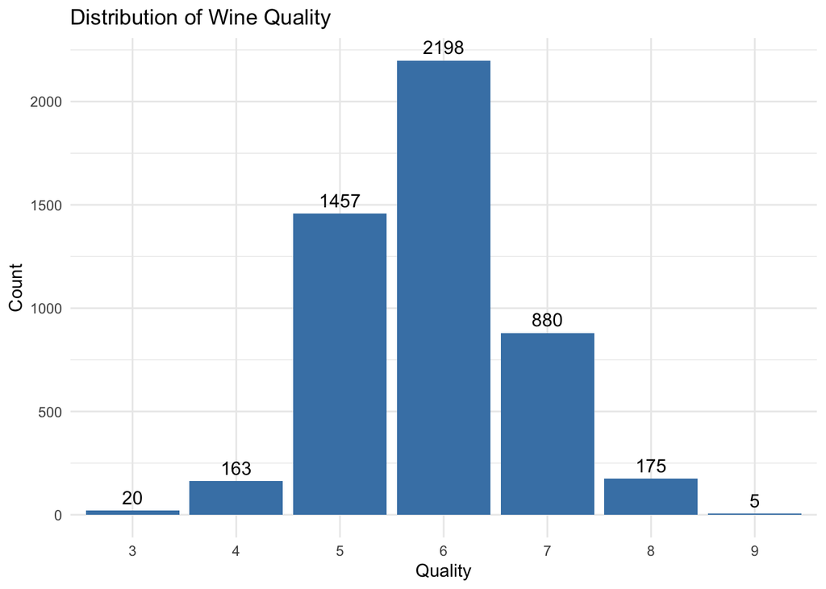

```r
# Plot the distribution of the 'quality' column
ggplot(WhiteWine, aes(x = as.factor(quality))) +
  geom_bar(fill = "steelblue") +
  geom_text(stat = "count", aes(label = ..count..), vjust = -0.5, size = 4) +
  labs(x = "Quality", y = "Count", title = "Distribution of Wine Quality") +
  theme_minimal()
```

**comment**

Please see the Python version of the Assignment

#### 4. The dataset’s info file contains a note saying that “several of the attributes may be correlated.” Create a correlogram to visualize the correlation between the variables. What can you infer from the correlogram?

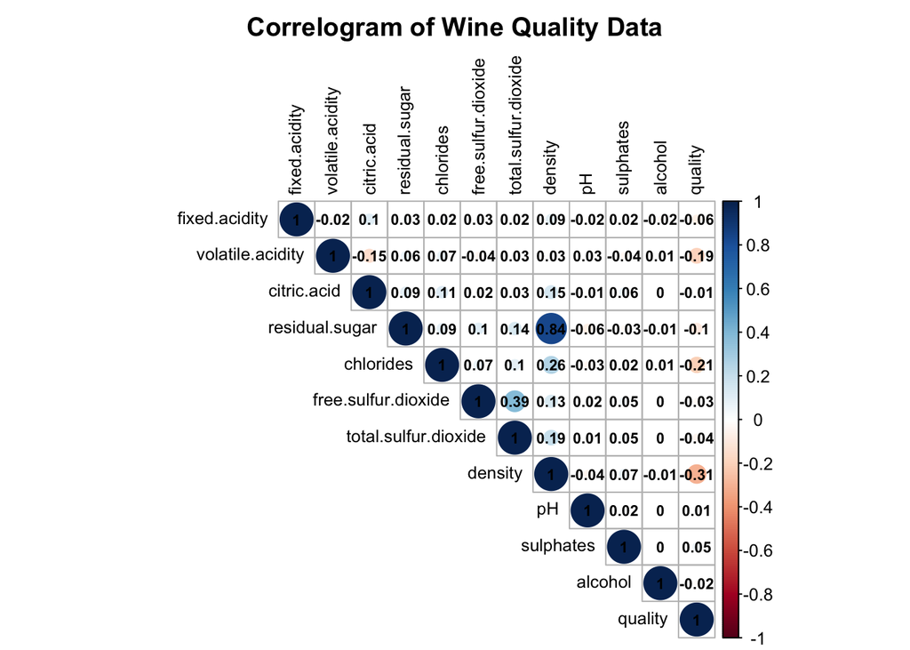

```r
# Clean the column names (remove spaces and special characters)
colnames(WhiteWine) <- make.names(colnames(WhiteWine), unique = TRUE)

# convert character columns to numeric
WhiteWine$volatile.acidity <- as.numeric(WhiteWine$volatile.acidity)
WhiteWine$citric.acid <- as.numeric(WhiteWine$citric.acid)
WhiteWine$residual.sugar <- as.numeric(WhiteWine$residual.sugar)
WhiteWine$chlorides <- as.numeric(WhiteWine$chlorides)
WhiteWine$sulphates <- as.numeric(WhiteWine$sulphates)
WhiteWine$density <- as.numeric(WhiteWine$density)

# Calculate the correlation matrix for all variables
corr_matrix <- cor(WhiteWine[, sapply(WhiteWine, is.numeric)])

# Create the correlogram
library(corrplot)
corrplot(corr_matrix, method = "circle", type = "upper",
         tl.col = "black", tl.cex = 0.8, addCoef.col = "black",
         number.cex = 0.7, title = "Correlogram of Wine Quality Data", mar = c(0,0,2,0))
```

**comment**

Please see the Python version of the Assignment

### Part III: Data Preprocessing

#### 5. Create a new column quality_cat that categorizes the quality of the wine into four categories: low, medium, high, and prestigious. The categories should be based on the following criteria: low for quality ratings below 5, medium for quality ratings of 5 and 6, high for quality ratings of 7 and 8, and prestigious for quality ratings above 8.

```r
# Create the 'quality_cat' column
WhiteWine <- WhiteWine %>%
  mutate(quality_cat = case_when(
    quality < 5 ~ "low",
    quality %in% c(5, 6) ~ "medium",
    quality %in% c(7, 8) ~ "high",
    quality > 8 ~ "prestigious"
  ))

# Display the first few rows to verify the new column
head(WhiteWine[, c("quality", "quality_cat")], 10)
```

```
## # A tibble: 10 × 2
##    quality quality_cat
##      <dbl> <chr>
##  1       6 medium
##  2       6 medium
##  3       6 medium
##  4       6 medium
##  5       6 medium
##  6       6 medium
##  7       6 medium
##  8       6 medium
##  9       6 medium
## 10       6 medium
```

#### 6. Split the dataset into a training and a test set. Use 70% of the data for training and 30% for testing.To make sure your results are reproducible, use 42 as seed.

```r
set.seed(42)

# Calculate the number of rows for training
n <- nrow(WhiteWine)
train_indices <- sample(1:n, size = 0.7 * n)

# Create training and test sets
train_set <- WhiteWine[train_indices, ]
test_set <- WhiteWine[-train_indices, ]

# Verify the split
cat("Training set size:", nrow(train_set), "\n")
```

```
## Training set size: 3428
```

```r
cat("Test set size:", nrow(test_set), "\n")
```

```
## Test set size: 1470
```

### Part IV: Machine Learning

#### 7. Explain why logistic a regression is not a suitable model for this dataset.

**Comment**

Please see the Python version of the Assignment

#### 8. Train a K-Nearest Neighbors model to predict the quality of the wine. You may need to prepare the data for use with the model. Make sure your training process is reproducible.

```r
# Remove 'quality_cat' before normalization
train_features <- train_set[, !(names(train_set) %in% c("quality", "quality_cat"))]
test_features <- test_set[, !(names(test_set) %in% c("quality", "quality_cat"))]

# Normalize numeric features
normalize <- function(x) (x - min(x)) / (max(x) - min(x))
train_set_scaled <- as.data.frame(lapply(train_features, normalize))
test_set_scaled <- as.data.frame(lapply(test_features, normalize))

# Extract the target variable
train_labels <- train_set$quality
test_labels <- test_set$quality

# Train the KNN model
predictions <- knn(train = train_set_scaled, test = test_set_scaled, cl = train_labels, k = 5)
```

#### 9. Train a random forest with 10 trees to predict the quality of the wine. You may need to prepare the data for use with the model. Make sure your training process is reproducible. In R, change the engine to “ranger” (ranger is a fast implementation of random forests for high dimensional data).

```r
library(ranger)
# Convert quality to factor for classification
train_set$quality <- as.factor(train_set$quality)
test_set$quality <- as.factor(test_set$quality)

# Combine scaled data with the quality column
train_set_final <- data.frame(train_set_scaled, quality = train_set$quality)
test_set_final <- data.frame(test_set_scaled, quality = test_set$quality)

# Train the Random Forest model using the ranger engine
rf_model <- ranger(
  formula = quality ~ .,
  data = train_set_final,
  num.trees = 10,
  seed = 42,
  importance = 'impurity'
)
```

#### 10. Evaluate the performance of the models using the test set. Inspect the confusion matrix and report the accuracy of the models. Do you see any problems with this classification?

```r
###### Performance of KNN ######
# Evaluate the model
conf_matrix <- table(predictions, test_labels)
accuracy <- sum(diag(conf_matrix)) / sum(conf_matrix)

print("Confusion Matrix for KNN:")
```

```
## [1] "Confusion Matrix for KNN:"
```

```r
print(conf_matrix)
```

```
##            test_labels
## predictions   3   4   5   6   7   8
##           3   0   0   0   0   0   0
##           4   0   2   0   0   0   0
##           5   1   5  39  32   9   1
##           6   4  30 281 369 151  21
##           7   4  14 138 219  92  11
##           8   0   1  13  21  10   2
##           9   0   0   0   0   0   0
```

```r
cat("Accuracy KNN:", accuracy, "\n")
```

```
## Accuracy KNN: 0.3428571
```

```r
###### Performance of Random Forest ######
# Make predictions
predictions <- predict(rf_model, data = test_set_final)$predictions

# Evaluate the model
conf_matrix <- table(predictions, test_set_final$quality)
accuracy <- sum(diag(conf_matrix)) / sum(conf_matrix)

# Output the results
print(paste("Accuracy Random Forest:", accuracy))
```

```
## [1] "Accuracy Random Forest: 0.412925170068027"
```

```r
print("Confusion Matrix for Random Forest:")
```

```
## [1] "Confusion Matrix for Random Forest:"
```

```r
print(conf_matrix)
```

```
##
## predictions   3   4   5   6   7   8
##           3   0   0   0   0   0   0
##           4   0   9   3   6   0   0
##           5   1  11  75  43   4   0
##           6   6  25 318 423 156  22
##           7   2   6  69 161  97  10
##           8   0   1   6   8   5   3
##           9   0   0   0   0   0   0
```

**comment**

Please see the Python version of the Assignment

#### 11. What would be a naïve baseline for this prediction task? Are your models better than this naïve baseline?

**comment**

Please see the Python version of the Assignment

#### 12. There is a second dataset for red wine quality ratings, winequality-red.csv. Use your best model to predict the quality of the red wine. You may need to prepare the data for this prediction. Inspect the confusion matrix. What is the accuracy of the model on the red wine dataset? Is it better than a naïve baseline?

```r
# Load the red wine dataset
red_wine <- read.csv2("./data/winequality-red.csv")

# Convert character columns to numeric
red_wine[] <- lapply(red_wine, function(x) {
  if (is.character(x)) as.numeric(x) else x
})


# Preprocess the red wine dataset
red_wine_final <- red_wine
red_wine_final[, -which(names(red_wine_final) == "quality")] <- scale(
  red_wine[, -which(names(red_wine) == "quality")]
)

# Predict using the trained Random Forest model
red_wine_predictions <- predict(rf_model, data = red_wine_final)$predictions

# Confusion Matrix
conf_matrix <- table(red_wine_predictions, red_wine$quality)
print("Confusion Matrix:")
```

```
## [1] "Confusion Matrix:"
```

```r
print(conf_matrix)
```

```
##
## red_wine_predictions   3   4   5   6   7   8
##                    3   0   0   0   0   0   0
##                    4   2  24 154  92  15   0
##                    5   2   9 224 185  40   3
##                    6   5  14 248 284 117  12
##                    7   1   5  51  72  27   3
##                    8   0   1   4   5   0   0
##                    9   0   0   0   0   0   0
```

```r
# Accuracy
accuracy <- sum(diag(conf_matrix)) / sum(conf_matrix)
print(paste("Accuracy:", accuracy))
```

```
## [1] "Accuracy: 0.349593495934959"
```

```r
# Naive Baseline
naive_baseline <- max(table(red_wine$quality)) / nrow(red_wine)
print(paste("Naive Baseline Accuracy:", naive_baseline))
```

```
## [1] "Naive Baseline Accuracy: 0.425891181988743"
```

**comment**

Please see the Python version of the Assignment

| **END OF SOLUTION** |
| --- |